# Name: Tanner Woods

# Imports

```python
import datetime
import warnings
import numpy as np
import pandas as pd
import yfinance as yf
import seaborn as sns
import itertools as it
import matplotlib.pyplot as plt
import statsmodels.formula.api as smf


from sklearn.model_selection import train_test_split as tts
from statsmodels.graphics.tsaplots import plot_acf, plot_pacf
```

```python
sns.set(font_scale = 1.2)
pd.set_option('display.max_columns', None)
warnings.simplefilter(action='ignore', category=FutureWarning)
```

# Question 1

## Question 1A

```python
Sentiment = pd.read_excel('Bull_Bear_Spread.xlsx', parse_dates = True, index_col = 0)
Sentiment = Sentiment[Sentiment.index <= '2022-12-23']
Sentiment.index = pd.to_datetime(Sentiment.index)

Market = yf.download('^GSPC', start='1987-07-13', end='2022-12-22', interval='1wk')[['Adj Close']].pct_change().dropna()
Market = Market.rename(columns={'Adj Close': 'Market'})

rf_rate = pd.read_csv('1-year-treasury-rate-yield-chart.csv', index_col = 0, parse_dates = True).ffill()
rf_rate.columns = ['RFR']
rf_rate = rf_rate.resample('7D').mean()/100

Data = pd.merge_asof(Sentiment, Market, left_index = True, right_index = True)
Data = pd.merge_asof(Data, rf_rate, left_index = True, right_index = True)
Data.dropna()
Data
```

```
[*********************100%***********************]  1 of 1 completed
```

| Date | Close | Market | RFR |
| --- | --- | --- | --- |
| 1987-07-24 | 0.220000 | -0.016911 | 0.067640 |
| 1987-07-31 | 0.000000 | 0.030362 | 0.069100 |
| 1987-08-07 | 0.270000 | 0.013620 | 0.069540 |
| 1987-08-14 | 0.250000 | 0.034025 | 0.069180 |
| 1987-08-21 | 0.600000 | 0.005719 | 0.070400 |
| ... | ... | ... | ... |
| 2022-11-24 | -0.113702 | 0.015328 | 0.047650 |
| 2022-12-01 | -0.159574 | 0.011321 | 0.047280 |
| 2022-12-08 | -0.170909 | -0.033725 | 0.047160 |
| 2022-12-15 | -0.203187 | -0.020847 | 0.046360 |
| 2022-12-22 | -0.320000 | -0.007780 | 0.046343 |

1847 rows × 3 columns

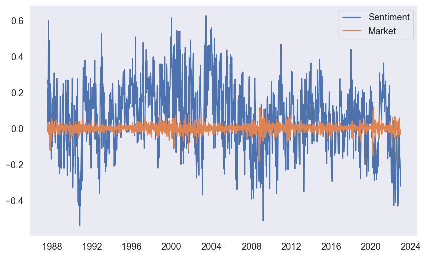

```python
plt.figure(figsize = (10, 6))

plt.plot(Data['Close'], label = 'Sentiment')
plt.plot(Data['Market'], label = 'Market')
plt.grid()
plt.legend()
plt.show()
```

```python
# specify candidate values for hyperparameters
ks = np.linspace(0.1, 0.9, 9)
zs = np.linspace(0.1, 3, 9)
ws = np.arange(1, 24, 3)
hs = np.arange(1, 16, 1)

import itertools as it
# build a grid with all possible hyperparameters
grid = np.array(np.meshgrid(ks,zs,ws,hs)).T.reshape(-1,4)

optimism_diffs = Data.copy()
optimism_diffs["returns"] = optimism_diffs["Market"].diff()
optimism_diffs
```

| Date | Close | Market | RFR | returns |
| --- | --- | --- | --- | --- |
| 1987-07-24 | 0.220000 | -0.016911 | 0.067640 | NaN |
| 1987-07-31 | 0.000000 | 0.030362 | 0.069100 | 0.047273 |
| 1987-08-07 | 0.270000 | 0.013620 | 0.069540 | -0.016742 |
| 1987-08-14 | 0.250000 | 0.034025 | 0.069180 | 0.020405 |
| 1987-08-21 | 0.600000 | 0.005719 | 0.070400 | -0.028306 |
| ... | ... | ... | ... | ... |
| 2022-11-24 | -0.113702 | 0.015328 | 0.047650 | 0.022237 |
| 2022-12-01 | -0.159574 | 0.011321 | 0.047280 | -0.004007 |
| 2022-12-08 | -0.170909 | -0.033725 | 0.047160 | -0.045047 |
| 2022-12-15 | -0.203187 | -0.020847 | 0.046360 | 0.012879 |
| 2022-12-22 | -0.320000 | -0.007780 | 0.046343 | 0.013067 |

1847 rows × 4 columns

For my strategy, I decided on applying the usual filter with an interval of z*(Standard dev. of optimism differences). While this is likely more than a little conservative, my reasoning was that by "mostly" sticking with the population's sentiments I could be spared the worst downturns — and sadly the largest upswings. However, if sentiment is unreasonably hot or cold, then a standard deviation interval should catch these.

```python
storage = pd.DataFrame(columns = ["k", "z", "w", "h", "profits"])

for n in range(len(grid)):
    # Each loop we pull out the values for a new set of hyperparamters from the grid
    k,z,w,h= grid[n]

    # We fit a filter and CI using the next set of parameters
    optimism_diffs["Filter"] = optimism_diffs["Close"].ewm(alpha = k, adjust = False).mean()
    optimism_diffs["Filter Error"] = optimism_diffs["Close"] -optimism_diffs["Filter"]
    optimism_diffs["std"] = optimism_diffs["Filter Error"].rolling(int(w)).std()
    optimism_diffs["Upper"] = optimism_diffs["Filter"] + z*optimism_diffs["std"]
    optimism_diffs["Lower"] = optimism_diffs["Filter"] - z*optimism_diffs["std"]
    # Inverting test for contrarian strategy
    # Filter error
    optimism_diffs["test"] = np.where(optimism_diffs["Filter Error"].abs()>z*optimism_diffs["std"], 1, 0)*np.sign(optimism_diffs["Filter Error"])

    # create vectors where we can store information on signals and when the change is first signalled
    optimism_diffs["test2"] = 0
    optimism_diffs["signal"] = 0

    for j in optimism_diffs.index:
        # if there is a change in the signal, we want to take a position for teh next h periods
        if (optimism_diffs.loc[j, "test"] == -1) &  (optimism_diffs.shift().loc[j, "test"] != -1):
            optimism_diffs.loc[j:j+datetime.timedelta(h), "signal"] = 1
            optimism_diffs.loc[j, "test2"] = 1
        elif (optimism_diffs.loc[j, "test"] == 1) &  (optimism_diffs.shift().loc[j, "test"] != 1):
            optimism_diffs.loc[j:j+datetime.timedelta(h), "signal"] =  -1
            optimism_diffs.loc[j, "test2"] = -1

# calculate metric
    optimism_diffs["cumulative_returns"] = (np.exp((optimism_diffs["signal"].shift()*optimism_diffs["returns"]).cumsum())-1)*100

    # store the results
    storage = storage.append({"k":k, "z":z, "w":w, "h":h ,"profits":optimism_diffs["cumulative_returns"][-1]}, ignore_index = True)
    #print so I can track progress of loop (can take a few minutes)
    #print(n)
```

[output not shown]

[output cut: 10 more lines]

[output not shown]

```python
## Gridsearch for parameters would die after about an hour or so
## Let it run as long as I could and then killed it
storage = storage.sort_values(by = "profits").reset_index(drop = True)
storage.tail(5)
```

|  | k | z | w | h | profits |
| --- | --- | --- | --- | --- | --- |
| 1259 | 0.5 | 0.825 | 16.0 | 1.0 | 3292.136848 |
| 1260 | 0.8 | 0.825 | 4.0 | 1.0 | 3454.881639 |
| 1261 | 0.8 | 0.825 | 4.0 | 2.0 | 3454.881639 |
| 1262 | 0.6 | 0.825 | 13.0 | 1.0 | 3808.990710 |
| 1263 | 0.6 | 0.825 | 13.0 | 2.0 | 3808.990710 |

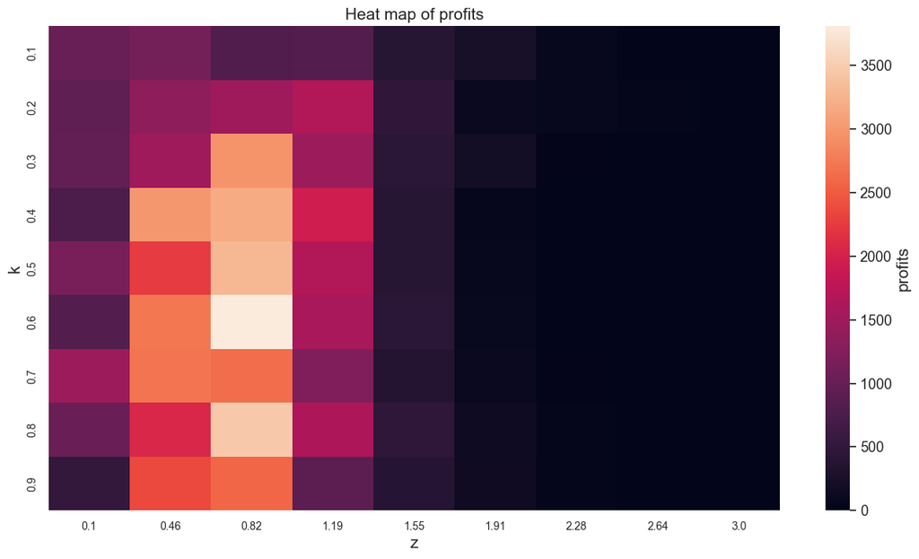

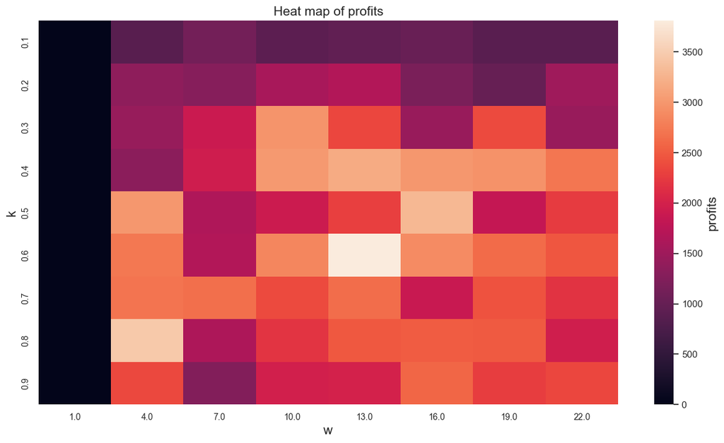

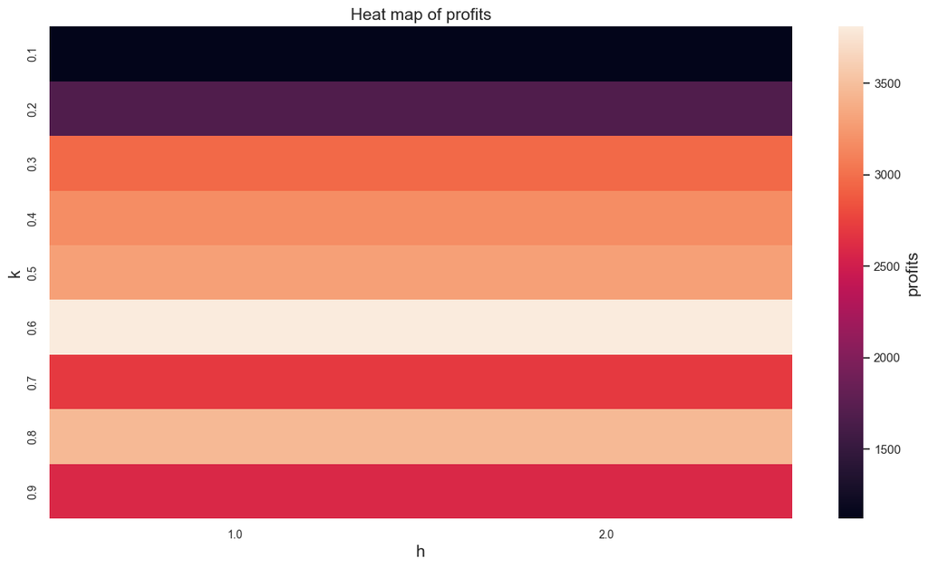

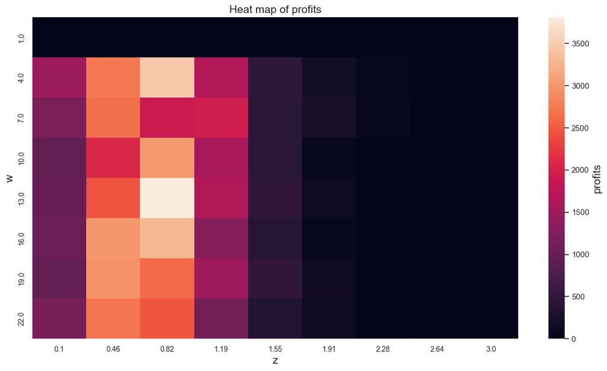

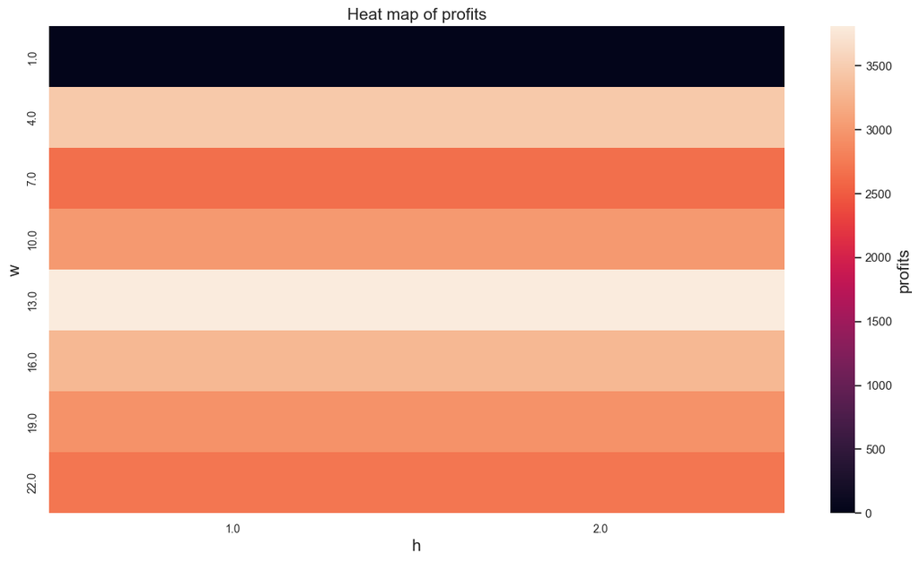

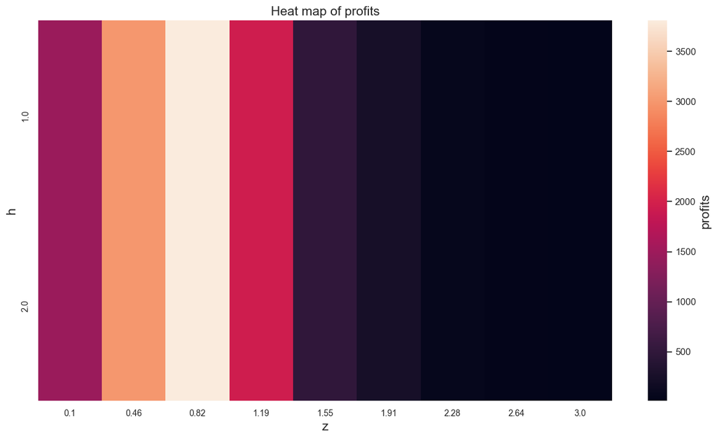

```python
# Heatmaps

def heatmap(x, y, metric, values):

    # specify the columns I will be pulling from the results
    p2p = values[[x, y, metric]]

    # If p > 2, we need to group
    heat = np.round(p2p.groupby([x,y]).max(),1)
    heat = heat.unstack()[metric]

    # round labels
    heat.index = np.round(heat.index,2)
    heat.columns = np.round(heat.columns,2)

    # make plot
    f, ax = plt.subplots(figsize=(15, 8))
    ax = sns.heatmap(heat, fmt='.1g')
    ax.set_title("Heat map of "+ metric,size = 15)
    ax.tick_params(axis='both', which='major', labelsize=10)
    ax.set_xlabel(y, size = 15)
    ax.set_ylabel(x, size = 15)
    ax.collections[0].colorbar.set_label(metric, size = 15)
    sns.set(font_scale=1)
    plt.show()

# Heatmap for Hyperparameters
heatmap("k", "z", "profits", storage)
heatmap("k", "w", "profits", storage)
heatmap("k", "h", "profits", storage)

heatmap("w", "z", "profits", storage)
heatmap("w", "h", "profits", storage)

heatmap("h", "z", "profits", storage)
```

```python
# According to the tables, the set of hyper-parameters that
    # produce the largest profits are:
print('Final Hyper-Parameters:')
k, z, w, h, profits = storage.iloc[-1]
print('k:', k)
print('z:', z)
print('w:', w)
print('h:', h)
print('Profits:', profits)

optimism_diffs = Data.copy()
optimism_diffs["returns"] = optimism_diffs["Market"].diff()

optimism_diffs["Filter"] = optimism_diffs["Close"].ewm(alpha = k, adjust = False).mean()
optimism_diffs["Filter Error"] = optimism_diffs["Close"] -optimism_diffs["Filter"]
optimism_diffs["std"] = optimism_diffs["Filter Error"].rolling(int(w)).std()
optimism_diffs["Upper"] = optimism_diffs["Filter"] + z*optimism_diffs["std"]
optimism_diffs["Lower"] = optimism_diffs["Filter"] - z*optimism_diffs["std"]
# Inverting test for contrarian strategy
# Filter error
optimism_diffs["test"] = np.where(optimism_diffs["Filter Error"].abs()>z*optimism_diffs["std"], 1, 0)*np.sign(optimism_diffs["Filter Error"])

# create vectors where we can store information on signals and when the change is first signalled
optimism_diffs["test2"] = 0
optimism_diffs["signal"] = 0

for j in optimism_diffs.index:
    # if there is a change in the signal, we want to take a position for teh next h periods
    if (optimism_diffs.loc[j, "test"] == -1) &  (optimism_diffs.shift().loc[j, "test"] != -1):
        optimism_diffs.loc[j:j+datetime.timedelta(h), "signal"] = 1
        optimism_diffs.loc[j, "test2"] = 1
    elif (optimism_diffs.loc[j, "test"] == 1) &  (optimism_diffs.shift().loc[j, "test"] != 1):
        optimism_diffs.loc[j:j+datetime.timedelta(h), "signal"] =  -1
        optimism_diffs.loc[j, "test2"] = -1

optimism_diffs["cumulative_returns"] = (np.exp((optimism_diffs["signal"].shift()*optimism_diffs["returns"]).cumsum())-1)*100
```

```
Final Hyper-Parameters:
k: 0.6
z: 0.825
w: 13.0
h: 2.0
Profits: 3808.990710129683
```

## Question 1B

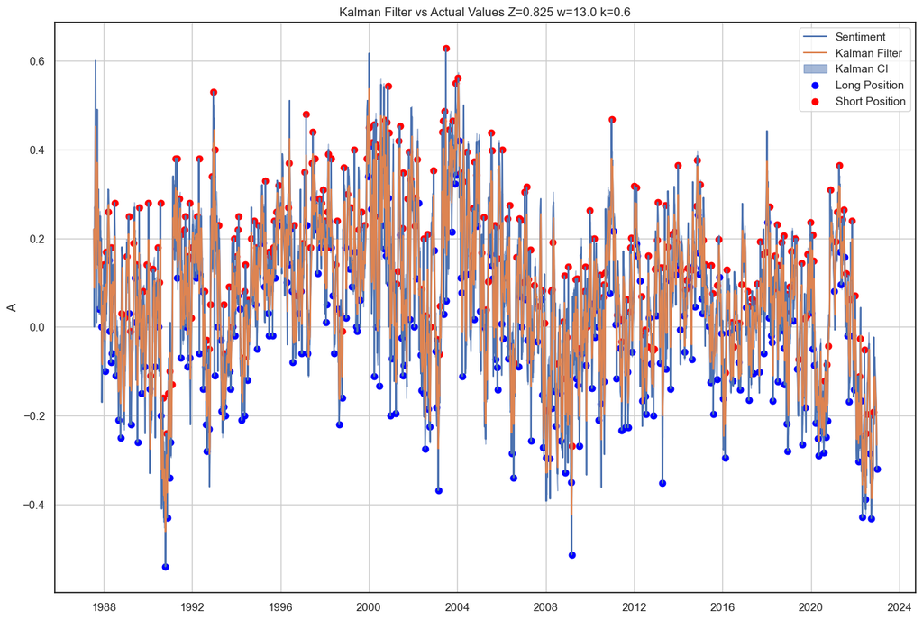

```python
# Visulizing the PE, the Kalman CI, Long & Short Positions
sns.set_style("white")
fig, ax = plt.subplots(figsize = (15, 10))
ax.set_title("Kalman Filter vs Actual Values " +
             "Z="+str(z) + " w=" + str(w)+ " k=" + str(k))

ax.set_ylabel("A")
ax.plot(optimism_diffs["Close"])
ax.plot(optimism_diffs["Filter"])


ax.fill_between(optimism_diffs.index, optimism_diffs.Lower,
                optimism_diffs.Upper, color='b', alpha=.5)
ax.scatter(optimism_diffs[optimism_diffs.test2 == 1].index,
           optimism_diffs[optimism_diffs.test2 == 1]["Close"], color = "blue")
ax.scatter(optimism_diffs[optimism_diffs.test2 == -1].index,
           optimism_diffs[optimism_diffs.test2 == -1]["Close"], color = "red")

#ax.axvline(df_copy.index[-5], color = "red", linestyle = '--')
ax.legend(["Sentiment", "Kalman Filter", 'Kalman CI',
           "Long Position", "Short Position"])


#plt.xlim([datetime.date(2000, 1, 1), datetime.date(2004, 1, 1)])
ax.grid()
```

[figure not shown]

```python
### Plotting the Trading Positions

# Creating Success
success = ((optimism_diffs[optimism_diffs.test2 != 0]["cumulative_returns"].diff()>0)*1)
optimism_diffs["success"] = success.shift(-1)


# Plot
plt.figure(figsize = (15, 5))

plt.title("USUK and Trading Positions"+ ", Z = "
          +str(z) + ", w = " + str(w)+ ", k = " + str(k))
plt.ylabel("USUK")
plt.plot(optimism_diffs["Close"])

longsuccess = optimism_diffs[(optimism_diffs["success"] == 1) & (optimism_diffs["test2"] == 1)]
longfail = optimism_diffs[(optimism_diffs["success"] == 0) & (optimism_diffs["test2"] == 1)]
shortsuccess = optimism_diffs[(optimism_diffs["success"] == 1) & (optimism_diffs["test2"] == -1)]
shortfail = optimism_diffs[(optimism_diffs["success"] == 0) & (optimism_diffs["test2"] == -1)]

plt.scatter(longsuccess.index, longsuccess["Close"],
            color = 'blue', s = 50)
plt.scatter(longfail.index, longfail["Close"],
            color = 'blue', s = 50, marker = "x")

plt.scatter(shortsuccess.index, shortsuccess["Close"],
            color = 'red', s = 50)
plt.scatter(shortfail.index, shortfail["Close"],
            color = 'red', s = 50, marker = "x")

plt.legend(["USUK Exchange Rate", "Long Success", "Long Fail",
            "Short Success", "Short Fail"])
plt.grid()
```

[figure not shown]

```python
## Plotting the Equity Curve
plt.figure(figsize = (15, 5))
sns.set_style("white")
(optimism_diffs["cumulative_returns"]).plot()
plt.title("Price Earnings Strategy:"+ ", Z = "
          +str(z) + ", w = " + str(w)+ ", k = " + str(k))
plt.legend(["Equity Curve"])
plt.grid()
```

```python
optimism_diffs
```

| Date | Close | Market | RFR | returns | Filter | Filter Error | std | Upper | Lower | test | test2 | signal | cumulative_returns | success |
| --- | --- | --- | --- | --- | --- | --- | --- | --- | --- | --- | --- | --- | --- | --- |
| 1987-07-24 | 0.220000 | -0.016911 | 0.067640 | NaN | 0.220000 | 0.000000 | NaN | NaN | NaN | 0.0 | 0 | 0 | NaN | NaN |
| 1987-07-31 | 0.000000 | 0.030362 | 0.069100 | 0.047273 | 0.088000 | -0.088000 | NaN | NaN | NaN | -0.0 | 0 | 0 | 0.00000 | NaN |
| 1987-08-07 | 0.270000 | 0.013620 | 0.069540 | -0.016742 | 0.197200 | 0.072800 | NaN | NaN | NaN | 0.0 | 0 | 0 | 0.00000 | NaN |
| 1987-08-14 | 0.250000 | 0.034025 | 0.069180 | 0.020405 | 0.228880 | 0.021120 | NaN | NaN | NaN | 0.0 | 0 | 0 | 0.00000 | NaN |
| 1987-08-21 | 0.600000 | 0.005719 | 0.070400 | -0.028306 | 0.451552 | 0.148448 | NaN | NaN | NaN | 0.0 | 0 | 0 | 0.00000 | NaN |
| ... | ... | ... | ... | ... | ... | ... | ... | ... | ... | ... | ... | ... | ... | ... |
| 2022-11-24 | -0.113702 | 0.015328 | 0.047650 | 0.022237 | -0.112841 | -0.000861 | 0.052210 | -0.069768 | -0.155914 | -0.0 | 0 | 0 | 3808.99071 | NaN |
| 2022-12-01 | -0.159574 | 0.011321 | 0.047280 | -0.004007 | -0.140881 | -0.018693 | 0.048212 | -0.101105 | -0.180656 | -0.0 | 0 | 0 | 3808.99071 | NaN |
| 2022-12-08 | -0.170909 | -0.033725 | 0.047160 | -0.045047 | -0.158898 | -0.012011 | 0.045219 | -0.121592 | -0.196204 | -0.0 | 0 | 0 | 3808.99071 | NaN |
| 2022-12-15 | -0.203187 | -0.020847 | 0.046360 | 0.012879 | -0.185471 | -0.017716 | 0.044592 | -0.148683 | -0.222260 | -0.0 | 0 | 0 | 3808.99071 | NaN |
| 2022-12-22 | -0.320000 | -0.007780 | 0.046343 | 0.013067 | -0.266189 | -0.053811 | 0.041429 | -0.232009 | -0.300368 | -1.0 | 1 | 1 | 3808.99071 | NaN |

1847 rows × 14 columns

```python
P = 1000
A = (((optimism_diffs["cumulative_returns"]/P)+1)*P)[-1]
y = len(optimism_diffs.index)/12

## Tot. RoR = ...
z = (A-P)/P
print(f'The total rate of return on our strategy is approx. {np.round(z, 5)}, or {np.round(z*100, 3)}%.')
print('\n')

## Ann. RoR = (End Value / Start Value)^(1/(79/12)) - 1
ARS = ((A/P)**(1/y)-1)
print(f'The annualized rate of return of our strategy is approx {np.round(ARS, 5)}, or {np.round(ARS*100, 3)}%.')
print('\n')

## RoR on Held Positions
## May need to pick diff sector bc no test2 == -1
## Start_Hold = df_copy["cumulative_returns"][df_copy['test2'] == 1]
## End_Hold = df_copy["cumulative_returns"][df_copy['test2'] == -1]
RoR_H = ((optimism_diffs["cumulative_returns"] - P) + (optimism_diffs["cumulative_returns"][optimism_diffs['test2'] == 1] - P))/P

#RoR_H = (((optimism_diffs["cumulative_returns"][optimism_diffs['test2'] == 1]/100)+1))/P
print(f'The rate of return on held positions is approx. {np.round(RoR_H[-1], 5)}, or {np.round(RoR_H[-1]*100, 3)}%.')
print('\n')

## Sharpe Ratio = E[R_a - R_b]/(StDev_a)
R_a = optimism_diffs["cumulative_returns"].resample('1Y').mean()
R_b = optimism_diffs['RFR'].resample('1Y').mean()
StDev_a = np.std(optimism_diffs["cumulative_returns"].resample('1Y').mean())
Sharpe_R = np.mean(R_a - R_b)/StDev_a
print(f'The Sharpe Ratio of our strategy is approx. {np.round(Sharpe_R, 5)}')
print('\n')

## Gini coefficient = ...
def GINI_COEF(returns):
    # get the number of periods -> will allow us to calculate the areas
    periods = len(returns)

    # sort values and sum to calculate the lorenz curve
    LorenzCurve = np.cumsum(returns.sort_values(by = "returns"))
    # start from 0
    LorenzCurve = pd.DataFrame({ 'returns': [0]}).append(LorenzCurve)
    Line = LorenzCurve.copy()
    # Form the line that encompasses A and B
    Line["returns"] = np.arange(0,1+1/periods, 1/periods)*max(LorenzCurve["returns"])

    # calculate the area of A+B
    UpArea = 0
    for i in range(1,len(returns)):
        UpArea = UpArea + ((Line.iloc[i,:] - LorenzCurve.iloc[i,:] + Line.iloc[i-1,:] - LorenzCurve.iloc[i-1,:]) / 2)
    # calculate the area of A+B+C
    if min(LorenzCurve["returns"]) < 0:
        AllArea = (np.abs(min(LorenzCurve["returns"])) * periods) + ((max(LorenzCurve["returns"]) * periods)/2)
    else:
        AllArea = ((max(LorenzCurve["returns"]) * periods)/2)
    gini = UpArea / AllArea
    return(gini[0])

Gini = GINI_COEF(optimism_diffs[["returns"]])
print(f'The Gini coefficient of the strategy is approx. {np.round(Gini, 5)}')
```

[output not shown]

# Question 2

## Question 2A

The second-largest bank failure in the form of SVB by liquidity squeeze, as well as the FDIC assuming control of SVB shortly after its collapse.

## Question 2B

In my personal opinion, I believe that there will be the following effects:

1) **EUR:USD** --> Little-to-no adjustment in realistic terms, but knock-on effects across the Atlantic might result in a appreciation of USD as — while an flagging economy hurts everyone — the US has more economic inertia relative to European nations.

2) **10-Year US interest rates** --> Likely to maintain status quo; even if they should be rising.

3) **SP500** --> Likely remain flat with a perhaps an opportunity for a healthy recorrection downwards; the former being more likely given how detached the market seems to be from reality.

Hopefully without this coming back to bite me: I don't believe that SVB's failure is as drastic as it seems. Action was taken rapidly and most account holders appear to be already-wealthy individuals.

## Question 2C

From end-of-day March 8th to end-of-day March 9th:

1) **EUR:USD** --> Increased by 0.01 in favor of the EUR

2) **10-Year US interest rates** --> Decreased by ~0.228pp

3) **SP500** --> Decreased by 73.69 points

From end-of-day March 9th to end-of-day March 10th, the...

1) **EUR:USD** --> Increased by 0.01 in favor of the EUR; this would reach a cumulative 0.02 increase by 3/17

2) **10-Year US interest rates** --> Increased by ~0.009pp

3) **SP500** --> Decreased by 56.73 points

## Question 2D

I believe that the best explanation for why the SVB collapse didn't lead to a 2008-scale crisis is multi-faceted:

1) While large in asset holdings, SVB seems to serve a relatively self-contained clientele. This didn't prevent any and all runs on other banks, but did serve to limit the spread of panic.

2) As stated in the second article, the labor market is growing increasingly healthier the further out the country gets from the pandemic. High labor-force participation and fair wages create a much more robust economic foundation.

3) The public opinion of the financial industry was never particularly high to begin with, but the 2008 crash and coronavirus certainly haven't done much besides lower it. I wouldn't be surprised if the limited panic was due to most individuals — referring back to the second point — being relatively stable in their finances and not fussed about investors losing their money.